# Baseline Risk Analysis for Burkina Faso

Analysis last updated 2021-03-26

This is an initial exploration into humanitarian risks and vulnerabilities in Burkina Faso. Data is compiled and presented on the following elements:

- [Flooding risk](https://geonode.wfp.org//layers/geonode%3Abfa_ica_floodrisk_geonode_20180712)
- [Drought risk](https://geonode.wfp.org//layers/geonode%3Abfa_ica_droughtrisk_geonode_20180712)
- [Population](https://data.humdata.org/dataset/burkina-faso-population-statistic)
- [Internally displaced persons](https://data.humdata.org/dataset/situation-des-personnes-deplacees-internes)
- [Food security](https://data.humdata.org/dataset/cadre-harmonise)
- [Poverty](https://data.humdata.org/dataset/burkina-faso-mpi)
- [Operational presence](https://data.humdata.org/dataset/burkina-faso-presence-operationnelle)
- [Seasonal precipitation forecast](https://iri.columbia.edu/our-expertise/climate/forecasts/seasonal-climate-forecasts/)

These factors vary across regions as shown by the figure below.

## Geographic overview of key factors

The North-Eastern regions of Burkina Faso (eg. Sahel, Centre-Nord) are more vulnerable, with high flood and drought risk. These regions also have a population more vulnerable to food insecurity and larger number of IDPs relative to the rest of the country. The country’s humanitarian presence is also most focused on these regions.

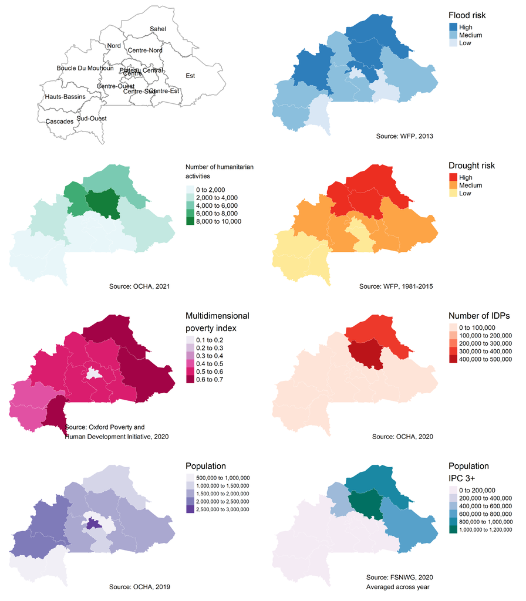

## Tabular overview of key factors

Risk, vulnerability, and capacity factors by region

| Region | Humanitarian activities | IDPs | Multidimensional poverty index | Drought risk | Flood risk | Total population | IPC Phase 3+ |
| --- | --- | --- | --- | --- | --- | --- | --- |
| Boucle Du Mouhoun | 3346 | 44902 | 0.5622305 | Medium | High | 2030595 | 193571 |
| Cascades | 770 | 8098 | 0.4995544 | Low | Medium | 851276 | 29770 |
| Centre | 149 | 1051 | 0.1968493 | Low | Low | 2966307 | 176731 |
| Centre-Est | 426 | 28446 | 0.5643588 | Medium | Low | 1655846 | 100075 |
| Centre-Nord | 8819 | 433597 | 0.5727177 | High | High | 1736152 | 1031924 |
| Centre-Ouest | 466 | 11126 | 0.5323436 | Medium | Medium | 1689721 | 93461 |
| Centre-Sud | 174 | 4008 | 0.5271575 | Low | Medium | 1197207 | 56611 |
| Est | 3254 | 71394 | 0.6603258 | Medium | Medium | 1834166 | 635900 |
| Hauts-Bassins | 401 | 20571 | 0.4481049 | Low | Medium | 2190829 | 109102 |
| Nord | 6191 | 76953 | 0.5681285 | High | Medium | 1677542 | 432805 |
| Plateau Central | 185 | 15199 | 0.5283065 | Medium | High | 975568 | 67305 |
| Sahel | 4206 | 352402 | 0.6550872 | High | High | 1437848 | 927167 |
| Sud-Ouest | 269 | 7246 | 0.6176171 | Low | Low | 891529 | 74309 |

## Populations facing high hazard risk

We see a greater total population in regions facing high flooding risk. By this factor alone, we could perhaps estimate that flooding would have a larger humanitarian impact.

Populations vulnerable to high hazard risk

|  | Total population | Men over 60 | Women over 60 | IDPs |
| --- | --- | --- | --- | --- |
| Flood | 6180163 | 131946 | 152521 | 846100 |
| Drought | 4851542 | 106773 | 126579 | 862952 |

## Number of humanitarian activities by cluster

This figure shows that a significant majority of humanitarian activities are within the WASH cluster, with a notable number also for Nutrition and Health.

Also see [this page](https://app.powerbi.com/view?r=eyJrIjoiNjgyYTM1ZjQtNzFhMC00OTUwLWFiYWYtZDdlN2VjMjE2Y2NkIiwidCI6IjBmOWUzNWRiLTU0NGYtNGY2MC1iZGNjLTVlYTQxNmU2ZGM3MCIsImMiOjh9&pageName=ReportSection) for a more detailed breakdown.

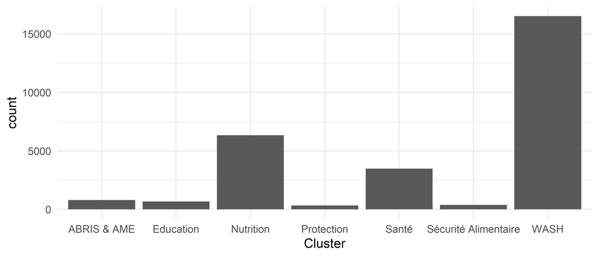

## Precipitation forecast across Africa, April-May-June

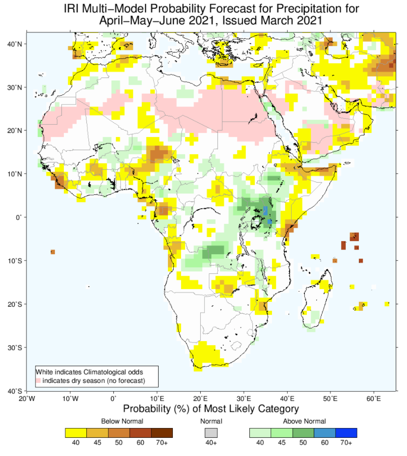